# Portfolio Drugs

Veethacheng Thao

We will need and use tidyverse to handle data importing and wrangling.

```r
install.packages("tidyverse", repos = "http://cran.us.r-project.org")
library("tidyverse")
drugs_survey <- read_csv("https://raw.githubusercontent.com/deepak525/Drug-Consumption/master/drug_consumption.csv")
```

When looking into the dataset we see that some of the column names was unclear so we can rename them to help us better understand the table.

```r
colnames(drugs_survey)[colnames(drugs_survey)=="SS"] <- "Sensation"
```

Splitting up the dataset to different tables so we can have a better understanding of our datas with the help of tidr.

```r
library("dplyr")
library("tidyr")

drugs <- tibble(Age=drugs_survey$Age, Gender=drugs_survey$Gender, Education=drugs_survey$Education, Country=drugs_survey$Country, Ethnicity=drugs_survey$Ethnicity, Alcohol=drugs_survey$Alcohol, Amphet=drugs_survey$Amphet, Amyl=drugs_survey$Amyl, Benzos=drugs_survey$Benzos, Caff=drugs_survey$Caff, Cannabis=drugs_survey$Cannabis, Choc=drugs_survey$Choc, Coke=drugs_survey$Coke, Crack=drugs_survey$Crack, Ecstasy=drugs_survey$Ecstasy, Heroin=drugs_survey$Heroin, Ketamine=drugs_survey$Ketamine, Legalh=drugs_survey$Legalh, LSD=drugs_survey$LSD, Meth=drugs_survey$Meth, Mushrooms=drugs_survey$Mushrooms, Nicotine=drugs_survey$Nicotine, Semer=drugs_survey$Semer, VSA=drugs_survey$VSA)

scores <- tibble(Age=drugs_survey$Age, Gender=drugs_survey$Gender, Education=drugs_survey$Education, Country=drugs_survey$Country, Ethnicity=drugs_survey$Ethnicity, Nscore=drugs_survey$Nscore, Escore=drugs_survey$Escore, Oscore=drugs_survey$Oscore, Ascore=drugs_survey$Ascore, Cscore=drugs_survey$Cscore, Impulsive=drugs_survey$Impulsive, Sensation=drugs_survey$Sensation)
```

Since there are some columns that can only be specific levels we use as.factor to help us define them.

```r
drugs_survey$Gender <- as.factor(drugs_survey$Gender)
drugs_survey$Education <- as.factor(drugs_survey$Education)
drugs_survey$Country <- as.factor(drugs_survey$Country)
drugs_survey$Ethnicity <- as.factor(drugs_survey$Ethnicity)
```

Now we will use ggplot2 to visualize our data to better help us understand what is going on. We will specifically focus on cannabis.

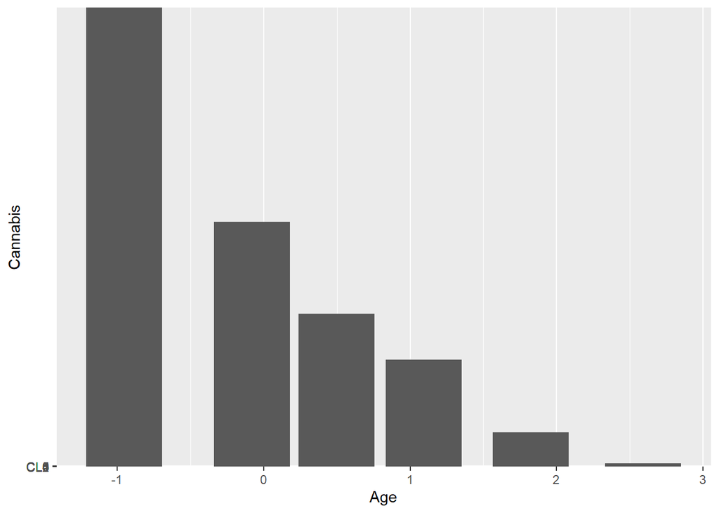

```r
library("ggplot2")
ggplot(drugs, aes(Age, Cannabis)) + geom_col()
```

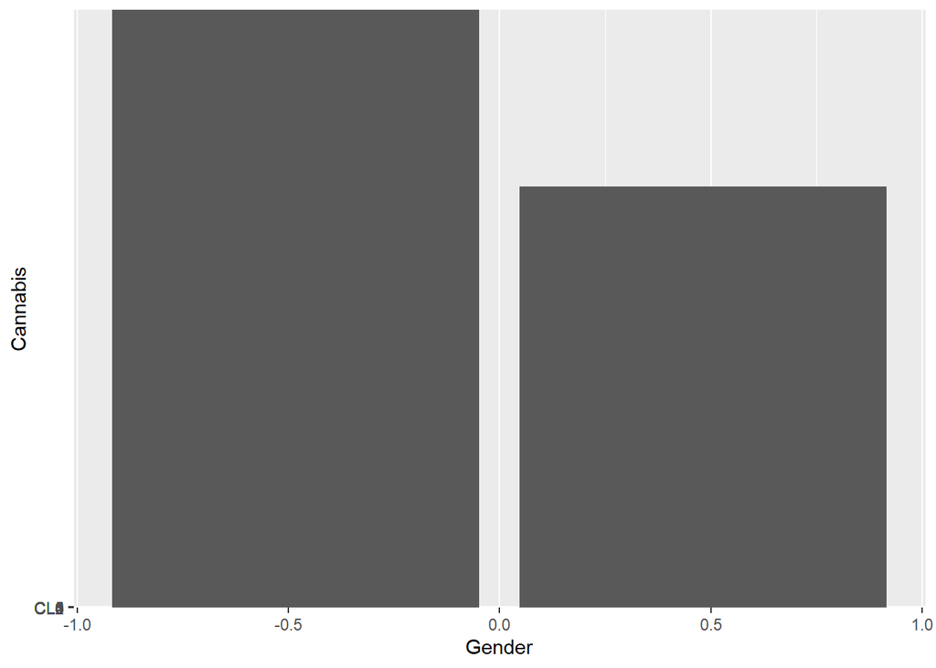

```r
ggplot(drugs, aes(Gender, Cannabis)) +  geom_col()
```

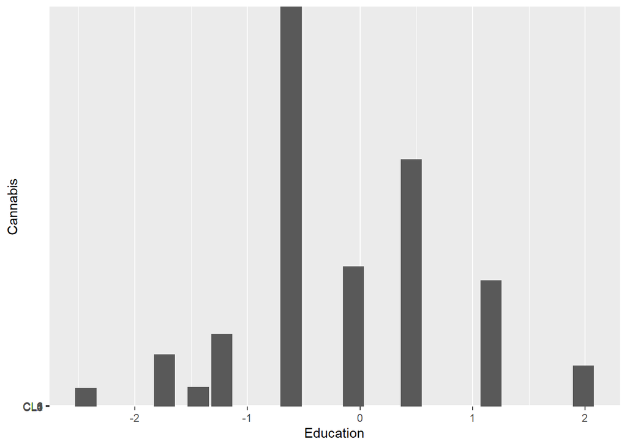

```r
ggplot(drugs, aes(Education, Cannabis)) +  geom_col()
```

To better understand what the values for these data are i have copy and paste the information i found from the person that collected these data below.

Age: Age is the age of participant and has one of the values:

Value Meaning Cases Fraction

-0.95197 18 - 24 643 34.11%

-0.07854 25 - 34 481 25.52%

0.49788 35 - 44 356 18.89%

1.09449 45 - 54 294 15.60%

1.82213 55 - 64 93 4.93%

2.59171 65+ 18 0.95%

3.Gender: Gender is gender of participant:

Value Meaning Cases Fraction

0.48246 Female 942 49.97%

-0.48246 Male 943 50.03%

Education: Education is level of education of participant and has one of the values:

Value Meaning Cases Fraction

-2.43591 Left School Before 16 years 28 1.49%

-1.73790 Left School at 16 years 99 5.25%

-1.43719 Left School at 17 years 30 1.59%

-1.22751 Left School at 18 years 100 5.31%

-0.61113 Some College,No Certificate Or Degree 506 26.84%

-0.05921 Professional Certificate/ Diploma 270 14.32%

0.45468 University Degree 480 25.46%

1.16365 Masters Degree 283 15.01%

1.98437 Doctorate Degree 89 4.72%

Country: Country is country of current residence of participant and has one of the values:

Value Meaning Cases Fraction

-0.09765 Australia 54 2.86%

0.24923 Canada 87 4.62%

-0.46841 New Zealand 5 0.27%

-0.28519 Other 118 6.26%

0.21128 Republic of Ireland 20 1.06%

0.96082 UK 1044 55.38%

-0.57009 USA 557 29.55%

6.Ethnicity: Ethnicity is ethnicity of participant and has one of the values:

Value Meaning Cases Fraction

-0.50212 Asian 26 1.38%

-1.10702 Black 33 1.75%

1.90725 Mixed-Black/Asian 3 0.16%

0.12600 Mixed-White/Asian 20 1.06%

-0.22166 Mixed-White/Black 20 1.06%

0.11440 Other 63 3.34%

-0.31685 White 1720 91.25%

Nscore: Nscore is NEO-FFI-R Neuroticism. Neuroticism is one of the Big Five higher-order personality traits in the study of psychology. Individuals who score high on neuroticism are more likely than average to be moody and to experience such feelings as anxiety, worry, fear, anger, frustration, envy, jealousy, guilt, depressed mood, and loneliness. Possible values are presented in table below:

Nscore Value Nscore Value Nscore Value Nscore Value

12 -3.46436 24 -1.32828 36 0.04257 48 1.23461

13 -3.15735 25 -1.19430 37 0.13606 49 1.37297

14 -2.75696 26 -1.05308 38 0.22393 50 1.49158

15 -2.52197 27 -0.92104 39 0.31287 51 1.60383

16 -2.42317 28 -0.79151 40 0.41667 52 1.72012

17 -2.34360 29 -0.67825 41 0.52135 53 1.83990

18 -2.21844 30 -0.58016 42 0.62967 54 1.98437

19 -2.05048 31 -0.46725 43 0.73545 55 2.12700

20 -1.86962 32 -0.34799 44 0.82562 56 2.28554

21 -1.69163 33 -0.24649 45 0.91093 57 2.46262

22 -1.55078 34 -0.14882 46 1.02119 58 2.61139

23 -1.43907 35 -0.05188 47 1.13281 59 2.82196

- - - - - - - - - - - - - - - - - - - 60 3.27393

EScore: Escore (Real) is NEO-FFI-R Extraversion. Extraversion is one of the five personality traits of the Big Five personality theory. It indicates how outgoing and social a person is. A person who scores high in extraversion on a personality test is the life of the party. They enjoy being with people, participating in social gatherings, and are full of energy. Possible values are presented in table below:

Escore Value Escore Value Escore Value Escore Value

16 -3.27393 27 -1.76250 38 -0.30033 49 1.45421

17 -3.00537 28 -1.63340 39 -0.15487 50 1.58487

18 -3.00537 29 -1.50796 40 0.00332 51 1.74091

19 -2.72827 30 -1.37639 41 0.16767 52 1.93886

20 -2.53830 31 -1.23177 42 0.32197 53 2.12700

21 -2.44904 32 -1.09207 43 0.47617 54 2.32338

22 -2.32338 33 -0.94779 44 0.63779 55 2.57309

23 -2.21069 34 -0.80615 45 0.80523 56 2.85950

24 -2.11437 35 -0.69509 46 0.96248 57 2.85950

25 -2.03972 36 -0.57545 47 1.11406 58 3.00537

26 -1.92173 37 -0.43999 48 1.28610 59 3.27393

Oscore: Oscore (Real) is NEO-FFI-R Openness to experience. Openness is one of the five personality traits of the Big Five personality theory. It indicates how open-minded a person is. A person with a high level of openness to experience in a personality test enjoys trying new things. They are imaginative, curious, and open-minded. Individuals who are low in openness to experience would rather not try new things. They are close-minded, literal and enjoy having a routine. Possible values are presented in table below:

Oscore Value Oscore Value Oscore Value

24 -3.27393 38 -1.11902 50 0.58331

26 -2.85950 39 -0.97631 51 0.72330

28 -2.63199 40 -0.84732 52 0.88309

29 -2.39883 41 -0.71727 53 1.06238

30 -2.21069 42 -0.58331 54 1.24033

31 -2.09015 43 -0.45174 55 1.43533

32 -1.97495 44 -0.31776 56 1.65653

33 -1.82919 45 -0.17779 57 1.88511

35 -1.55521 47 0.14143 59 2.44904

36 -1.42424 48 0.29338 60 2.90161

37 -1.27553 49 0.44585 NaN NaN

Ascore: Ascore(Real) is NEO-FFI-R Agreeableness. Agreeableness is one of the five personality traits of the Big Five personality theory. A person with a high level of agreeableness in a personality test is usually warm, friendly, and tactful. They generally have an optimistic view of human nature and get along well with others. Possible values are presented in table below:

Ascore Value Ascore Value Ascore Value

12 -3.46436 34 -1.34289 48 0.76096

16 -3.15735 35 -1.21213 49 0.94156

18 -3.00537 36 -1.07533 50 1.11406

23 -2.90161 37 -0.91699 51 1.2861

24 -2.78793 38 -0.76096 52 1.45039

25 -2.70172 39 -0.60633 53 1.61108

26 -2.53830 40 -0.45321 54 1.81866

27 -2.35413 41 -0.30172 55 2.03972

28 -2.21844 42 -0.15487 56 2.23427

29 -2.07848 43 -0.01729 57 2.46262

30 -1.92595 44 0.13136 58 2.75696

31 -1.77200 45 0.28783 59 3.15735

32 -1.62090 46 0.43852 60 3.46436

33 -1.47955 47 0.59042 NaN NaN

Cscore: Cscore (Real) is NEO-FFI-R Conscientiousness. Conscientiousness is one of the five personality traits of the Big Five personality theory. A person scoring high in conscientiousness usually has a high level of self-discipline. These individuals prefer to follow a plan, rather than act spontaneously. Their methodic planning and perseverance usually makes them highly successful in their chosen occupation. Possible values are presented in table below:

Cscore Value Cscore Value Cscore Value

17 -3.46436 32 -1.25773 46 0.58489

19 -3.15735 33 -1.13788 47 0.7583

20 -2.90161 34 -1.01450 48 0.93949

21 -2.72827 35 -0.89891 49 1.13407

22 -2.57309 36 -0.78155 50 1.30612

23 -2.42317 37 -0.65253 51 1.46191

24 -2.30408 38 -0.52745 52 1.63088

25 -2.18109 39 -0.40581 53 1.81175

26 -2.04506 40 -0.27607 54 2.04506

27 -1.92173 41 -0.14277 55 2.33337

28 -1.78169 42 -0.00665 56 2.63199

29 -1.64101 43 0.12331 57 3.00537

30 -1.51840 44 0.25953 59 3.46436

31 -1.38502 45 0.41594 NaN NaN

Impulsive: Impulsive (Real) is impulsiveness measured by BIS-11. In psychology, impulsivity (or impulsiveness) is a tendency to act on a whim, displaying behavior characterized by little or no forethought, reflection, or consideration of the consequences. If you describe someone as impulsive, you mean that they do things suddenly without thinking about them carefully first. Possible values are presented in table below:

Impulsiveness Cases Fraction

-2.55524 20 1.06%

-1.37983 276 14.64%

-0.71126 307 16.29%

-0.21712 355 18.83%

0.19268 257 13.63%

0.52975 216 11.46%

0.88113 195 10.34%

1.29221 148 7.85%

1.86203 104 5.52%

2.90161 7 0.37%

Sensation: SS(Real) is sensation seeing measured by ImpSS. Sensation is input about the physical world obtained by our sensory receptors, and perception is the process by which the brain selects, organizes, and interprets these sensations. In other words, senses are the physiological basis of perception. Possible values are presented in table below:

SS Cases Fraction

-2.07848 71 3.77%

-1.54858 87 4.62%

-1.18084 132 7.00%

-0.84637 169 8.97%

-0.52593 211 11.19%

-0.21575 223 11.83%

0.07987 219 11.62%

0.40148 249 13.21%

0.76540 211 11.19%

1.22470 210 11.14%

1.92173 103 5.46%

The remaining columns are divided inti 7 classes:

Value Description

CL0 Never Used

CL1 Used over a Decade Ago

CL2 Used in Last Decade

CL3 Used in Last Year

CL4 Used in Last Month

CL5 Used in Last Week

CL6 Used in Last Day

In my later phases of my portfolio i want to see how deadly these drugs are. Also I want to know which of these drugs is beneficial.